# Module03HW

Diana McSpadden

2/20/2021

# Module 3 Homework

## H. Diana McSpadden (hdm5s)

## 2021-02-22

Complete exercises 5, 10, and 11 at the end of Chapter 4 (pp. 168–173) of your textbook.

Start on page 168

## 5. Differences between LDA and QDA.

### (a) If the Bayes decision boundary is linear, …

do we expect LDA or QDA to perform better on the training set? On the test set?  
**Answer Q5a**: We would expect linear discriminant analysis to operate with more accuracy if the actual relationship can be separated by a linear boundary, because models will behave best when their assumptions most closely match the reality of the data set. I would expect LDA to perform much better on the *test* data set. On the training data set LDA and QDA may perform similarly.

### (b) If the Bayes decision boundary is non-linear, …

do we expect LDA or QDA to perform better on the training set? On the test set?  
**Answer Q5b**: I would expect QDA to perform better both with the training and the test data sets.

### (c) In general, as the sample size n increases, do we expect …

the test prediction accuracy of QDA relative to LDA to improve, decline,or be unchanged? Why?  
Our textbook confirms that QDA should perform better than LDA as n increases, and that QDA is recommended when the training set is “very large.” A very large training will reduce the variance problem (over-fitting) that will affect a more flexible model, i.e. the QDA model.

**Answer Q5c**:

## 10. This question should be answered using the Weekly data set, …

which is part of the ISLR package. This data is similar in nature to the Smarket data from this chapter’s lab, except that it contains 1,089 weekly returns for 21 years, from the beginning of 1990 to the end of 2010.

### (a) Produce some numerical and graphical summaries of the Weekly data. Do there appear to be any patterns?

```r
names(Weekly)
```

```
## [1] "Year"      "Lag1"      "Lag2"      "Lag3"      "Lag4"      "Lag5"
## [7] "Volume"    "Today"     "Direction"
```

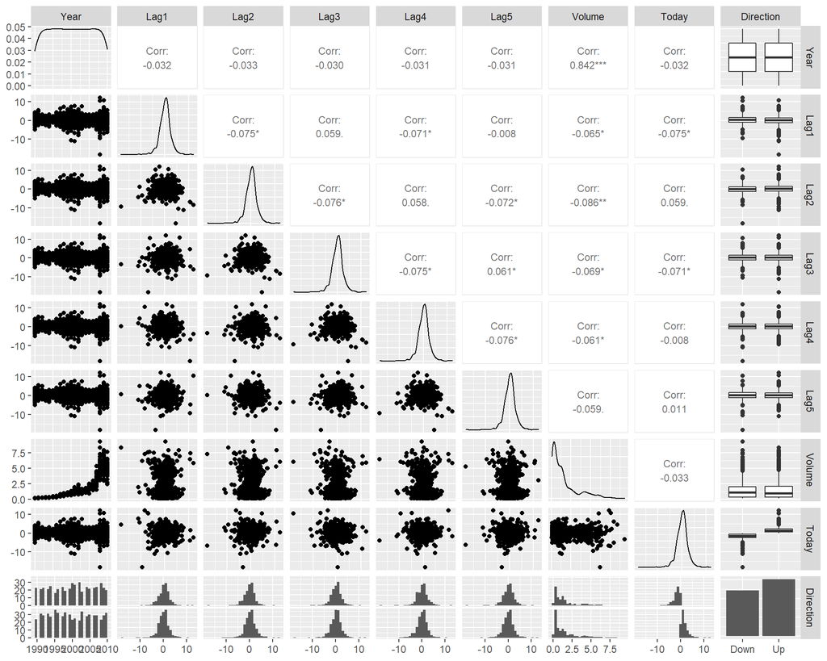

```r
Weekly %>% ggpairs(upper=list(continuous=wrap("cor", size=3)), progress = F)
```

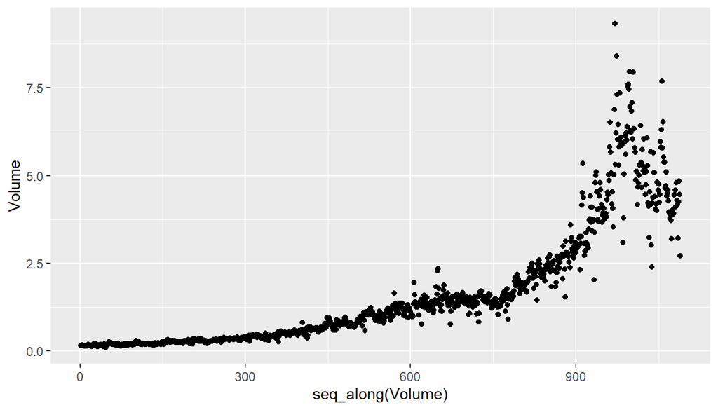

```r
Weekly %>% dplyr::select(Volume) %>%
  ggplot(aes(x=seq_along(Volume), y=Volume)) + geom_point()
```

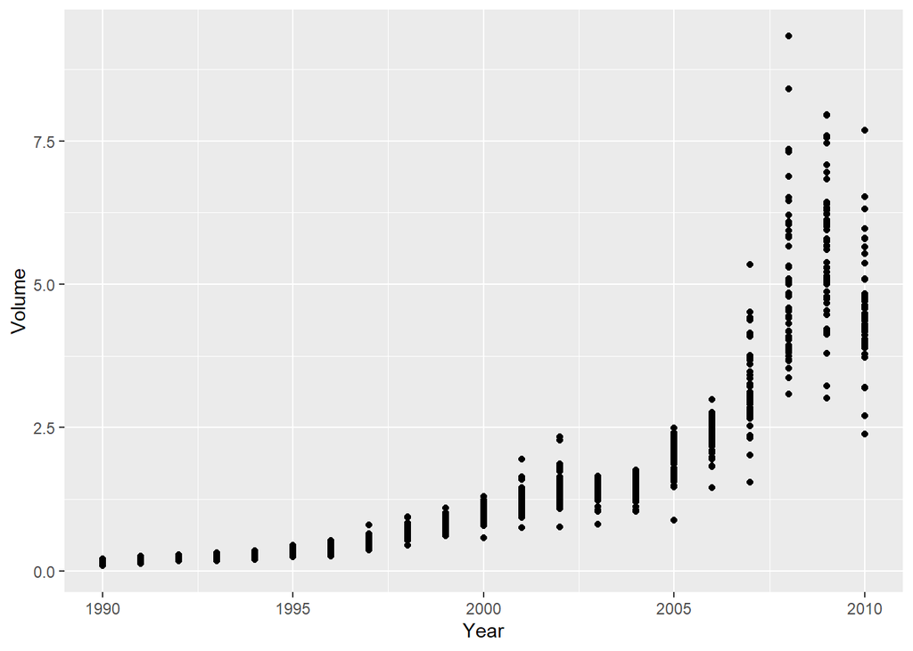

```r
Weekly %>% dplyr::select(Volume, Year) %>%
  ggplot(aes(x=Year, y=Volume)) + geom_point()
```

```r
Weekly %>% dplyr::group_by(Direction) %>%
  summarize(N = n()) %>%
  mutate(Perc = round(N/ sum(N), 2) * 100)
```

```
## # A tibble: 2 x 3
##   Direction     N  Perc
## * <fct>     <int> <dbl>
## 1 Down        484   44
## 2 Up          605   56.
```

**Answer Q10a**: As with the Smarket data set, there are no correlations, other than Volume to year. From the sequential scatter plot of Volume, and Volumne by year scatter plot it is clear that Volume increased and had greater variance in the more recent data.  
It also appears that Lag1, Lag2, Lag3, Lag4, Lag5, and Today are all near-normally distributed.  
There are 484 ‘Down’ days in the data and 605 ‘Up’ days (56%). If we guessed ‘Up’ for each day we would have greater accuracy than flipping a coin.

### (b) Use the full data set to perform a logistic regression …

with Direction as the response and the five lag variables plus Volume as predictors. Use the summary function to print the results. Do any of the predictors appear to be statistically significant? If so, which ones?

```r
weekly.mod.log = glm(Direction~Lag1+Lag2+Lag3+Lag4+Lag5+Volume, data=Weekly,family=binomial)
#weekly.mod.log %>% glance()
weekly.mod.log %>% tidy()
```

```
## # A tibble: 7 x 5
##   term        estimate std.error statistic p.value
##   <chr>          <dbl>     <dbl>     <dbl>   <dbl>
## 1 (Intercept)   0.267     0.0859     3.11  0.00190
## 2 Lag1         -0.0413    0.0264    -1.56  0.118
## 3 Lag2          0.0584    0.0269     2.18  0.0296
## 4 Lag3         -0.0161    0.0267    -0.602 0.547
## 5 Lag4         -0.0278    0.0265    -1.05  0.294
## 6 Lag5         -0.0145    0.0264    -0.549 0.583
## 7 Volume       -0.0227    0.0369    -0.616 0.538
```

```r
summary(weekly.mod.log)
```

```
##
## Call:
## glm(formula = Direction ~ Lag1 + Lag2 + Lag3 + Lag4 + Lag5 +
##     Volume, family = binomial, data = Weekly)
##
## Deviance Residuals:
##     Min       1Q   Median       3Q      Max
## -1.6949  -1.2565   0.9913   1.0849   1.4579
##
## Coefficients:
##             Estimate Std. Error z value Pr(>|z|)
## (Intercept)  0.26686    0.08593   3.106   0.0019 **
## Lag1        -0.04127    0.02641  -1.563   0.1181
## Lag2         0.05844    0.02686   2.175   0.0296 *
## Lag3        -0.01606    0.02666  -0.602   0.5469
## Lag4        -0.02779    0.02646  -1.050   0.2937
## Lag5        -0.01447    0.02638  -0.549   0.5833
## Volume      -0.02274    0.03690  -0.616   0.5377
## ---
## Signif. codes:  0 '***' 0.001 '**' 0.01 '*' 0.05 '.' 0.1 ' ' 1
##
## (Dispersion parameter for binomial family taken to be 1)
##
##     Null deviance: 1496.2  on 1088  degrees of freedom
## Residual deviance: 1486.4  on 1082  degrees of freedom
## AIC: 1500.4
##
## Number of Fisher Scoring iterations: 4
```

```r
#weekly.mod.log %>% tidy() %>% dplyr::select(estimate)
```

**Answer Q10b**: Only *Lag2* is significant in this model. Unlike the Smarket data set, Lag 2 is positively correlated with the “1”/positive class.

### (c) Compute the confusion matrix and overall fraction of correct predictions.

Explain what the confusion matrix is telling you about the types of mistakes made by logistic regression.

```r
weekly.mod.log.logOdds_predictions <- weekly.mod.log %>% augment() %>%
  dplyr::select(Direction, .fitted)  %>%
  mutate(.prediction=ifelse(.fitted<0, "Down", "Up")) %>%
  mutate(.prediction=fct_relevel(as_factor(.prediction), c("Down", "Up")))

#weekly.mod.log.logOdds_predictions %>% conf_mat(Direction, .prediction)
#(507+145)/1250
library(caret)
caret::confusionMatrix(weekly.mod.log.logOdds_predictions$.prediction,
                       weekly.mod.log.logOdds_predictions$Direction)
```

```
## Confusion Matrix and Statistics
##
##           Reference
## Prediction Down  Up
##       Down   54  48
##       Up    430 557
##
##                Accuracy : 0.5611
##                  95% CI : (0.531, 0.5908)
##     No Information Rate : 0.5556
##     P-Value [Acc > NIR] : 0.369
##
##                   Kappa : 0.035
##
##  Mcnemar's Test P-Value : <2e-16
##
##             Sensitivity : 0.11157
##             Specificity : 0.92066
##          Pos Pred Value : 0.52941
##          Neg Pred Value : 0.56434
##              Prevalence : 0.44444
##          Detection Rate : 0.04959
##    Detection Prevalence : 0.09366
##       Balanced Accuracy : 0.51612
##
##        'Positive' Class : Down
##
```

**Answer Q10b**:

**Sensitivity**, or the “True Positive Rate” is 11%  
**Specificity**, or “True Negative Rate” is 92%  
**Total Accuracy** is **0.56**

Down is the “positive” class in this case; this model may be useful in identifying up days. Our model does not perform well predicting “down” days. This model did predict 92% of the true “Up” days.

### (d) Now fit the logistic regression model using a training data period from 1990 to 2008, …

with Lag2 as the only predictor. Compute the confusion matrix and the overall fraction of correct predictions for the held out data (that is, the data from 2009 and 2010).

```r
summary(Weekly$Year)
```

```
##    Min. 1st Qu.  Median    Mean 3rd Qu.    Max.
##    1990    1995    2000    2000    2005    2010
```

Setup the training and test data sets, and confirm dimensions.

```r
Weekly %>% dim()
```

```
## [1] 1089    9
```

```r
Weekly = Weekly %>% mutate(train = case_when(Year < 2009 ~ 1, TRUE~0))
```

```r
Weekly.train = Weekly %>% filter(train == 1)
Weekly.test = Weekly %>% filter(train == 0)

Weekly.train %>% dim()
```

```
## [1] 985  10
```

```r
Weekly.test %>% dim()
```

```
## [1] 104  10
```

```r
weekly.mod.log.train = glm(Direction~Lag2, data=Weekly.train,family=binomial)
#weekly.mod.log.train %>% tidy()
weekly.mod.log.train.logOdds_predictions = weekly.mod.log.train %>% augment(newdata=Weekly.test) %>%
  dplyr::select(Direction, .fitted)  %>%
  mutate(.prediction=ifelse(.fitted<0, "Down", "Up")) %>%
  mutate(.prediction=fct_relevel(as_factor(.prediction), c("Down", "Up")))


caret::confusionMatrix(weekly.mod.log.train.logOdds_predictions$.prediction,
                       weekly.mod.log.train.logOdds_predictions$Direction)
```

```
## Confusion Matrix and Statistics
##
##           Reference
## Prediction Down Up
##       Down    9  5
##       Up     34 56
##
##                Accuracy : 0.625
##                  95% CI : (0.5247, 0.718)
##     No Information Rate : 0.5865
##     P-Value [Acc > NIR] : 0.2439
##
##                   Kappa : 0.1414
##
##  Mcnemar's Test P-Value : 7.34e-06
##
##             Sensitivity : 0.20930
##             Specificity : 0.91803
##          Pos Pred Value : 0.64286
##          Neg Pred Value : 0.62222
##              Prevalence : 0.41346
##          Detection Rate : 0.08654
##    Detection Prevalence : 0.13462
##       Balanced Accuracy : 0.56367
##
##        'Positive' Class : Down
##
```

**‘Positive’ Class : Down**

**Log Sensitivity:** 0.21  
**Log Specificity:** 0.918  
**Total Accuracy or “fraction of correct predictions”:** (9+56) / 104 = **0.625**

### (e) Repeat (d) using LDA.

```r
weekly.train.lda.fit = lda(Direction~Lag2, data=Weekly.train)
#weekly.train.lda.fit

weekly.lda.pred = predict(weekly.train.lda.fit, Weekly.test) %>% purrr::map(as_tibble) %>%
  purrr::map(add_rownames) %>% purrr::reduce(left_join, by='rowname') %>%
  rename(prediction=value, posterior_Down=Down, posterior_Up=Up)
#weekly.lda.pred

Y = Weekly.test %>% dplyr::select(Direction)

weekly.lda.pred.augmented = weekly.lda.pred %>% add_column(Y)
weekly.lda.pred.augmented %>% conf_mat(Direction, prediction)
```

```
##           Truth
## Prediction Down Up
##       Down    9  5
##       Up     34 56
```

**‘Positive’ Class : Down**

**LDA Sensitivity:** 9 / 43 = 0.20  
**LDA Specificity:** 56 / 61 = 0.92  
**Total Accuracy:** (9+56) / 104 = **0.62**

### (f) Repeat (d) using QDA.

```r
weekly.train.qda.fit = qda(Direction~Lag2, data=Weekly.train)
#weekly.train.lda.fit

weekly.qda.pred = predict(weekly.train.qda.fit, Weekly.test) %>% purrr::map(as_tibble) %>%
  purrr::map(add_rownames) %>% purrr::reduce(left_join, by='rowname') %>%
  rename(prediction=value, posterior_Down=Down, posterior_Up=Up)
#weekly.lda.pred

weekly.qda.pred.augmented = weekly.qda.pred %>% add_column(Y)
weekly.qda.pred.augmented %>% conf_mat(Direction, prediction)
```

```
##           Truth
## Prediction Down Up
##       Down    0  0
##       Up     43 61
```

**‘Positive’ Class : Down**

**QDA Sensitivity:** 0 / 43 = 0.00  
**QDA Specificity:** 61 / 61 = 1.0  
**Total Accuracy:** (0+61) / 104 = **0.587**

### (g) Repeat (d) using KNN with K = 1.

Create my matrices:

```r
Weekly.X.train = Weekly.train %>% dplyr::select(Lag2) %>% as.matrix()
Weekly.X.train %>% dim()
```

```
## [1] 985   1
```

```r
Weekly.X.test = Weekly.test %>% dplyr::select(Lag2) %>% as.matrix()
Weekly.X.test %>% dim()
```

```
## [1] 104   1
```

```r
Weekly.Y.train = Weekly.train %>% dplyr::select(Direction) %>% as.matrix()
Weekly.Y.train %>% dim()
```

```
## [1] 985   1
```

```r
Weekly.Y.test = Weekly.test %>% dplyr::select(Direction)
Weekly.Y.test %>% dim()
```

```
## [1] 104   1
```

```r
tibble(yhat = knn(Weekly.X.train, Weekly.X.test, Weekly.Y.train, k=1), y = Weekly.Y.test[['Direction']]) %>%
  conf_mat(y, yhat)
```

```
##           Truth
## Prediction Down Up
##       Down   21 29
##       Up     22 32
```

**‘Positive’ Class : Down**

### (i) Experiment with different combinations of predictors, …

including possible transformations and interactions, for each of methods. Report the variables, method, and associated confusion matrix that appears to provide the best results on the held out data. Note that you should also experiment with values for K in the KNN classifier.

**Trying a square operator on Volume with our best performing model: the Log model. Experimenting with this because of the scatter plot of Volume to year.**

```r
weekly.mod.log.train = glm(Direction~Lag2+I(Volume^2), data=Weekly.train,family=binomial)
#weekly.mod.log.train %>% tidy()
weekly.mod.log.train.logOdds_predictions = weekly.mod.log.train %>% augment(newdata=Weekly.test) %>%
  dplyr::select(Direction, .fitted)  %>%
  mutate(.prediction=ifelse(.fitted<0, "Down", "Up")) %>%
  mutate(.prediction=fct_relevel(as_factor(.prediction), c("Down", "Up")))


caret::confusionMatrix(weekly.mod.log.train.logOdds_predictions$.prediction,
                       weekly.mod.log.train.logOdds_predictions$Direction)
```

```
## Confusion Matrix and Statistics
##
##           Reference
## Prediction Down Up
##       Down   18 20
##       Up     25 41
##
##                Accuracy : 0.5673
##                  95% CI : (0.4665, 0.6641)
##     No Information Rate : 0.5865
##     P-Value [Acc > NIR] : 0.6921
##
##                   Kappa : 0.0923
##
##  Mcnemar's Test P-Value : 0.5510
##
##             Sensitivity : 0.4186
##             Specificity : 0.6721
##          Pos Pred Value : 0.4737
##          Neg Pred Value : 0.6212
##              Prevalence : 0.4135
##          Detection Rate : 0.1731
##    Detection Prevalence : 0.3654
##       Balanced Accuracy : 0.5454
##
##        'Positive' Class : Down
##
```

**‘Positive’ Class : Down**

**Log Sensitivity:** 18 / 43 = 0.41  
**Log Specificity:** 41 / 61 = 0.67  
**Total Accuracy:** (18+41) / 104 = **0.567**

While this improves the sensitivity of the model (true positive rate), it caused a decrease in the specificity rate (true negative rate). The overall accuracy also decreased when compared to our simple logistic regression with Lag2.

```r
lda.trysq.1 = lda(Direction~Lag2+I(Volume^2), data=Weekly.train)
#weekly.train.lda.fit

lda.trysq.1.pred = predict(lda.trysq.1, Weekly.test) %>% purrr::map(as_tibble) %>%
  purrr::map(add_rownames) %>% purrr::reduce(left_join, by='rowname') %>%
  rename(prediction=value, posterior_Down=Down, posterior_Up=Up)

Y = Weekly.test %>% dplyr::select(Direction)

lda.trysq.1.pred.augmented = lda.trysq.1.pred %>% add_column(Y)
lda.trysq.1.pred.augmented %>% conf_mat(Direction, prediction)
```

```
##           Truth
## Prediction Down Up
##       Down   18 20
##       Up     25 41
```

**‘Positive’ Class : Down**

**LDA Sensitivity:** 18 / 43 = 0.41  
**LDA Specificity:** 41 / 61 = 0.67  
**Total Accuracy:** (18+41) / 104 = **0.567**

This is *interesting* because a LDA analysis model with a square of Volume performs the same as the logistic model with Volume squared.

```r
k_start = 30
k_end = 60
out_nvar = k_end - k_start + 1

output10_i = rep(NA, out_nvar)
sensitivity10_k = rep(NA, out_nvar)
specificity10_k = rep(NA, out_nvar)
balanced.accuracy10_k = rep(NA, out_nvar)


for (i in seq(1,30)){
  yhat = knn(Weekly.X.train, Weekly.X.test, Weekly.Y.train, k=i+29)

  k_confmatrix = caret::confusionMatrix(yhat, Weekly.Y.test$Direction)

  output10_i[i] = i+29
  sensitivity10_k[i] = confusionMatrix(data=yhat, reference=Weekly.Y.test[['Direction']], positive = "Down")$byClass["Sensitivity"]
  specificity10_k[i] = confusionMatrix(data=yhat, reference=Weekly.Y.test[['Direction']], positive = "Down")$byClass["Specificity"]
  balanced.accuracy10_k[i] = confusionMatrix(data=yhat, reference=Weekly.Y.test[['Direction']], positive = "Down")$byClass["Balanced Accuracy"]

  #print(caret::confusionMatrix(yhat, Auto.test$mpg01))
}

outcome10 = data.frame(output10_i,sensitivity10_k, specificity10_k, balanced.accuracy10_k)

outcome10
```

```
##    output10_i sensitivity10_k specificity10_k balanced.accuracy10_k
## 1          30       0.4418605       0.6065574             0.5242089
## 2          31       0.4418605       0.6065574             0.5242089
## 3          32       0.4883721       0.5737705             0.5310713
## 4          33       0.4883721       0.5901639             0.5392680
## 5          34       0.4883721       0.6229508             0.5556615
## 6          35       0.5116279       0.6065574             0.5590926
## 7          36       0.4418605       0.6393443             0.5406024
## 8          37       0.5116279       0.6065574             0.5590926
## 9          38       0.4883721       0.6065574             0.5474647
## 10         39       0.4883721       0.6393443             0.5638582
## 11         40       0.4883721       0.6229508             0.5556615
## 12         41       0.4883721       0.6065574             0.5474647
## 13         42       0.4883721       0.6229508             0.5556615
## 14         43       0.4651163       0.6065574             0.5358368
```

[output cut: 17 more lines]

## 11. In this problem, you will develop a model to predict…

whether a given car gets high or low gas mileage based on the Auto data set.

### (a) Create a binary variable, mpg01, that contains a 1 if mpg contains

a value above its median, and a 0 if mpg contains a value below its median. You can compute the median using the median() function.

```r
#head(Auto, 3)

Auto %>% dim()
```

```
## [1] 392   9
```

Make sure origin and mpg01 are factors.

```r
Auto %>% summarize(median(mpg))
```

```
##   median(mpg)
## 1       22.75
```

```r
Auto.working = Auto %>%
  mutate(mpg01 = case_when(mpg >= median(mpg) ~ 1, TRUE~0))

Auto.working$mpg01 = factor(Auto.working$mpg01)
Auto.working$origin = factor(Auto.working$origin)

head(Auto.working, 3)
```

```
##   mpg cylinders displacement horsepower weight acceleration year origin
## 1  18         8          307        130   3504         12.0   70      1
## 2  15         8          350        165   3693         11.5   70      1
## 3  18         8          318        150   3436         11.0   70      1
##                        name mpg01
## 1 chevrolet chevelle malibu     0
## 2         buick skylark 320     0
## 3        plymouth satellite     0
```

### (b) Explore the data graphically in order to investigate the association

between mpg01 and the other features. Which of the other features seem most likely to be useful in predicting mpg01? Scatter plots and box plots may be useful tools to answer this question. Describe your findings.

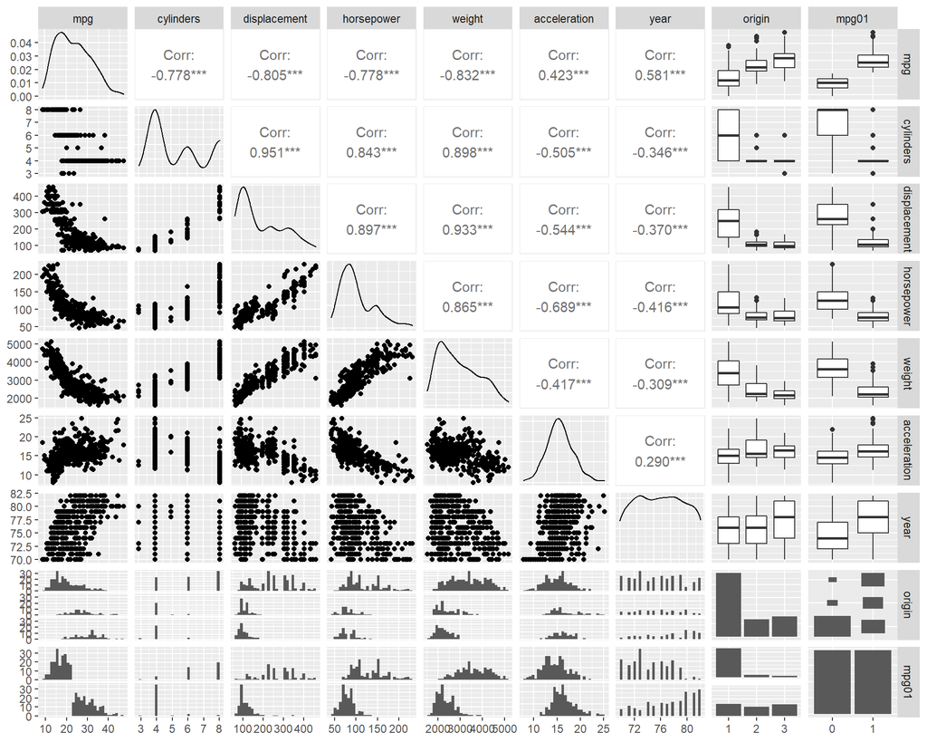

```r
 ggpairs(Auto.working[-9], progress = F)
```

### (c) Split the data into a training set and a test set.

Create a random group of 100 observations to set aside. Remove the column name from both the training and test sets.

```r
set.seed(1976)
train_indices <- sample(392, 292, replace=FALSE)

Auto.train <- Auto.working %>% slice(train_indices) %>% dplyr::select(-name)
Auto.test <- Auto.working %>% slice(-train_indices) %>% dplyr::select(-name)

print("Training Dims:")
```

```
## [1] "Training Dims:"
```

```r
Auto.train %>% dim()
```

```
## [1] 292   9
```

```r
print("Testing Dims:")
```

```
## [1] "Testing Dims:"
```

```r
Auto.test %>% dim()
```

```
## [1] 100   9
```

### (d) Perform LDA on the training data in order to predict mpg01

using the variables that seemed most associated with mpg01 in (b). What is the test error of the model obtained?

**Work on Q11d:**  
I create the LDA model. It uses 0 (below median) as the “positive class”:

```r
Auto.lda.fit = lda(mpg01~cylinders+displacement+horsepower+weight+year+origin, data=Auto.train)
#weekly.train.lda.fit

#predict(Auto.lda.fit, Auto.test) %>% map(as_tibble) %>%
#  map(add_rownames) %>% reduce(left_join, by='rowname')

Auto.lda.pred = predict(Auto.lda.fit, Auto.test) %>% map(as_tibble) %>%
  map(add_rownames) %>% reduce(left_join, by='rowname') %>%
  rename(prediction=value, posterior_0='0', posterior_1='1')

#Y = Auto.test %>% dplyr::select(mpg01)

#Auto.lda.pred = Auto.lda.pred %>% add_column(Y)
#Auto.lda.pred %>% conf_mat(mpg01, prediction)

caret::confusionMatrix(Auto.lda.pred$prediction, Auto.test$mpg01)
```

```
## Confusion Matrix and Statistics
##
##           Reference
## Prediction  0  1
##          0 41  0
##          1  8 51
##
##                Accuracy : 0.92
##                  95% CI : (0.8484, 0.9648)
##     No Information Rate : 0.51
##     P-Value [Acc > NIR] : < 2e-16
##
##                   Kappa : 0.8394
##
##  Mcnemar's Test P-Value : 0.01333
##
##             Sensitivity : 0.8367
##             Specificity : 1.0000
##          Pos Pred Value : 1.0000
##          Neg Pred Value : 0.8644
##              Prevalence : 0.4900
##          Detection Rate : 0.4100
##    Detection Prevalence : 0.4100
##       Balanced Accuracy : 0.9184
##
##        'Positive' Class : 0
##
```

### (e) Perform QDA on the training data in order to predict mpg01

using the variables that seemed most associated with mpg01 in (b). What is the test error of the model obtained?

```r
Auto.qda.fit = qda(mpg01~cylinders+displacement+horsepower+weight+year+origin, data=Auto.train)
#weekly.train.lda.fit

#predict(Auto.lda.fit, Auto.test) %>% map(as_tibble) %>%
#  map(add_rownames) %>% reduce(left_join, by='rowname')

Auto.qda.pred = predict(Auto.qda.fit, Auto.test) %>% map(as_tibble) %>%
  map(add_rownames) %>% reduce(left_join, by='rowname') %>%
  rename(prediction=value, posterior_0='0', posterior_1='1')

#Auto.qda.pred

#Auto.qda.pred = Auto.qda.pred %>% add_column(Y)


#Auto.qda.pred %>% conf_mat(Y, prediction)

caret::confusionMatrix(Auto.qda.pred$prediction, Auto.test$mpg01)
```

```
## Confusion Matrix and Statistics
##
##           Reference
## Prediction  0  1
##          0 41  1
##          1  8 50
##
##                Accuracy : 0.91
##                  95% CI : (0.836, 0.958)
##     No Information Rate : 0.51
##     P-Value [Acc > NIR] : <2e-16
##
##                   Kappa : 0.8194
##
##  Mcnemar's Test P-Value : 0.0455
##
##             Sensitivity : 0.8367
##             Specificity : 0.9804
##          Pos Pred Value : 0.9762
##          Neg Pred Value : 0.8621
##              Prevalence : 0.4900
##          Detection Rate : 0.4100
##    Detection Prevalence : 0.4200
##       Balanced Accuracy : 0.9086
##
##        'Positive' Class : 0
##
```

### (f) Perform logistic regression on the training data in order to predict

mpg01 using the variables that seemed most associated with mpg01 in (b). What is the test error of the model obtained?

```r
Auto.log.train = glm(mpg01~cylinders+displacement+horsepower+weight+year+origin, data=Auto.train, family=binomial)

Auto.log.predictions <- Auto.log.train %>% augment(newdata=Auto.test) %>%
  dplyr::select(mpg01, .fitted)  %>%
  mutate(.prediction=ifelse(.fitted<0, '0', '1')) %>%
  mutate(.prediction=fct_relevel(as_factor(.prediction), c("0", "1")))

#Auto.log.predictions %>% conf_mat(mpg01, .prediction)

caret::confusionMatrix(Auto.log.predictions$.prediction, Auto.test$mpg01)
```

```
## Confusion Matrix and Statistics
##
##           Reference
## Prediction  0  1
##          0 44  3
##          1  5 48
##
##                Accuracy : 0.92
##                  95% CI : (0.8484, 0.9648)
##     No Information Rate : 0.51
##     P-Value [Acc > NIR] : <2e-16
##
##                   Kappa : 0.8398
##
##  Mcnemar's Test P-Value : 0.7237
##
##             Sensitivity : 0.8980
##             Specificity : 0.9412
##          Pos Pred Value : 0.9362
##          Neg Pred Value : 0.9057
##              Prevalence : 0.4900
##          Detection Rate : 0.4400
##    Detection Prevalence : 0.4700
##       Balanced Accuracy : 0.9196
##
##        'Positive' Class : 0
##
```

### (g) Perform KNN on the training data, with several values of K, in

order to predict mpg01. Use only the variables that seemed most associated with mpg01 in (b). What test errors do you obtain? Which value of K seems to perform the best on this data set?

**Create my matrices:**

```r
Auto.X.train = Auto.train %>% dplyr::select(cylinders,displacement,horsepower,weight,year,origin) %>% as.matrix()
Auto.X.train %>% dim()
```

```
## [1] 292   6
```

```r
Auto.X.test = Auto.test %>% dplyr::select(cylinders,displacement,horsepower,weight,year,origin) %>% as.matrix()
Auto.X.test %>% dim()
```

```
## [1] 100   6
```

```r
Auto.Y.train = Auto.train %>% dplyr::select(mpg01) %>% as.matrix()
Auto.Y.train %>% dim()
```

```
## [1] 292   1
```

```r
Auto.Y.test = Auto.test %>% dplyr::select(mpg01)
Auto.Y.test %>% dim()
```

```
## [1] 100   1
```

```r
k_start = 1
k_end = 35
out_nvar = k_end - k_start + 1

output_i = rep(NA, out_nvar)
sensitivity_k = rep(NA, out_nvar)
specificity_k = rep(NA, out_nvar)
balanced.accuracy_k = rep(NA, out_nvar)


for (i in seq(1,35)){

  #confmatrix = tibble(yhat = knn(Auto.X.train, Auto.X.test, Auto.Y.train, k=i), y = Auto.Y.test[['mpg01']]) %>%
  #  conf_mat(y, yhat)

  yhat = knn(Auto.X.train, Auto.X.test, Auto.Y.train, k=i)

  k_confmatrix = caret::confusionMatrix(yhat, Auto.test$mpg01)

  output_i[i] = i
  sensitivity_k[i] = confusionMatrix(data=yhat, reference=Auto.Y.test[['mpg01']], positive = "1")$byClass["Sensitivity"]
  specificity_k[i] = confusionMatrix(data=yhat, reference=Auto.Y.test[['mpg01']], positive = "1")$byClass["Specificity"]
  balanced.accuracy_k[i] = confusionMatrix(data=yhat, reference=Auto.Y.test[['mpg01']], positive = "1")$byClass["Balanced Accuracy"]

  #print(caret::confusionMatrix(yhat, Auto.test$mpg01))
}

outcome = data.frame(output_i,sensitivity_k, specificity_k, balanced.accuracy_k)

outcome
```

```
##    output_i sensitivity_k specificity_k balanced.accuracy_k
## 1         1     0.9215686     0.7346939           0.8281313
## 2         2     0.9215686     0.6938776           0.8077231
## 3         3     0.9607843     0.7551020           0.8579432
## 4         4     0.9803922     0.7959184           0.8881553
## 5         5     0.9607843     0.7551020           0.8579432
## 6         6     0.9803922     0.7755102           0.8779512
## 7         7     0.9803922     0.7755102           0.8779512
## 8         8     0.9803922     0.7755102           0.8779512
## 9         9     0.9803922     0.7959184           0.8881553
## 10       10     0.9607843     0.7755102           0.8681473
## 11       11     0.9803922     0.7755102           0.8779512
## 12       12     0.9803922     0.8163265           0.8983593
## 13       13     0.9803922     0.7959184           0.8881553
## 14       14     0.9803922     0.7959184           0.8881553
```

[output cut: 21 more lines]

```r
yhat = knn(Auto.X.train, Auto.X.test, Auto.Y.train, k=25)

caret::confusionMatrix(yhat, Auto.test$mpg01)
```

```
## Confusion Matrix and Statistics
##
##           Reference
## Prediction  0  1
##          0 41  2
##          1  8 49
##
##                Accuracy : 0.9
##                  95% CI : (0.8238, 0.951)
##     No Information Rate : 0.51
##     P-Value [Acc > NIR] : <2e-16
##
##                   Kappa : 0.7994
##
##  Mcnemar's Test P-Value : 0.1138
##
##             Sensitivity : 0.8367
##             Specificity : 0.9608
##          Pos Pred Value : 0.9535
##          Neg Pred Value : 0.8596
##              Prevalence : 0.4900
##          Detection Rate : 0.4100
##    Detection Prevalence : 0.4300
##       Balanced Accuracy : 0.8988
##
##        'Positive' Class : 0
##
```

**Answer q11g**: My ***best** value of k was 25 when I compare sensitivity, specificity, and balanced accuracy. With a k of 25:  
**KNN | k=25 False Positive Rate:** 2 / 51 = **0.039**  
**KNN | k=25 False Negative Rate:** 8 / 49 = **0.163**

The QDA and Logistic Regression models both out performed the KNN, even with the best-tested k value.